# Google Apps 商店的数据分析

## 简介

相信大家对移动应用商店都不陌生吧。Google Play Store（Google Play商店）是谷歌官方的软件应用商店，拥有上架软件数十万款，下载量更是突破了20亿次，为了手机用户提供了极为广泛的应用选择，很受大家的欢迎。

本数据集(googleplaystore.csv)包含了 Google Play 商店中 App 的数据。该数据是Kaggle中 [Google Play Store Apps](https://www.kaggle.com/lava18/google-play-store-apps) 的一部分，其中包含 Google Play 商店中 10k+ 应用软件的信息。

数据中的变量含义解释：

```
App: 应用的名称，字符变量。
Category: 应用所属的分类，字符变量。
Rating: 某应用的用户评分，数值变量。
Reviews: 某应用获得的用户评论数量，数值变量。
Size: 某应用的所占存储空间的大小，字符变量。
Installs: 用户安装和下载某应用的次数，字符变量。
Type: 付费或免费，分类变量。
Price: 价格，字符变量。
Content Rating: 应用商店针对内容给出的年龄评级组 - Children / Mature 21+ / Adult，分类变量。
Genres: 类型/流派，一个应用可以属于多个流派，比如音乐、游戏、家庭等，字符变量。
Last Updated: 应用最新更新的日期，字符变量。
Current Ver: 当前应用的版本，字符变量。
Android Ver: 安装该应用所需要的最低安卓版本，字符变量。
```

## 项目完成指南

本项目中的数据分析流程已经给出，但代码将完全由你自己进行书写，如果你无法完成本项目，说明你目前的能力并不足以完成 数据分析(进阶)纳米学位，建议先进行 数据分析（入门）纳米学位的学习，掌握进阶课程的先修知识。

对于数据分析过程的记录也是数据分析报告的一个重要部分，你可以自己在需要的位置插入Markdown cell，记录你在数据分析中的关键步骤和推理过程。比如：数据有什么样的特点，统计数据的含义是什么，你从可视化中可以得出什么结论，下一步分析是什么，为什么执行这种分析。如果你无法做到这一点，你也无法通过本项目。

> **小贴士**: 像这样的引用部分旨在为学员提供实用指导，帮助学员了解并使用 Jupyter notebook

## 1 提出问题

在此项目中，你将以一名数据分析师的身份执行数据的探索性分析。你将了解数据分析过程的基本流程。在你分析数据之前，请先思考几个你需要了解的关于 Google 商店中应用的问题，例如，最受欢迎（下载量最高）的 Apps 有什么特征？哪些 App 的评分更高？

**问题**：请写下你感兴趣的问题，请确保这些问题能够由现有的数据进行回答。 （为了确保学习的效果，请确保你的数据分析报告中能够包含2幅可视化和1个相关性分析。）

1. 评分最高的APP是什么，以及什么类型的APP？
2. 评分最高的付费/免费APP分别是什么？
3. 付费类APP是否比免费类APP评分更高？
4. 付费类APP的评分与价格是否存在关系？
5. 下载量最高的APP是啥？
6. 评论数量与下载量是否正相关？
7. APP价格是否会影响其下载量？

**答案**：

在提出了问题之后，我们将开始导入数据，并对数据进行探索性分析，来回答上面提出的问题。

> **小贴士**: 双击上框，文本就会发生变化，所有格式都会被清除，以便你编辑该文本块。该文本块是用 [Markdown](http://daringfireball.net/projects/markdown/syntax)编写的，该语言使用纯文本语法，能用页眉、链接、斜体等来规范文本格式。在纳米学位课程中，你也会用到 Markdown。编辑后，可使用 **Shift** + **Enter** 或 **Shift** + **Return** 运行上该框，使其呈现出编辑好的文本格式。

## 2 数据评估和清理

> **小贴士**: 运行代码框的方法与编辑上方的 Markdown 框的格式类似，你只需点击代码框，按下键盘快捷键 **Shift** + **Enter** 或 **Shift** + **Return** ，或者你也可先选择代码框，然后点击工具栏的 **运行** 按钮来运行代码。运行代码框时，相应单元左侧的信息会出现星号，即 `In [*]:`，若代码执行完毕，星号则会变为某个数字，如 `In [1]`。如果代码运行后有输出结果，输出将会以 `Out [1]:` 的形式出现，其中的数字将与 "In" 中的数字相对应。

### 2.1 导入数据

```python
# 请先运行此代码块，以确保在可视化中可以显示中文
!rm -rf ~/.cache/matplotlib/fontList.json
!wget http://d.xiazaiziti.com/en_fonts/fonts/s/SimHei.ttf -O /opt/conda/lib/python3.6/site-packages/matplotlib/mpl-data/fonts/ttf/SimHei.ttf
import matplotlib.pyplot as plt

plt.rcParams['font.sans-serif']=['SimHei'] #用来正常显示中文标签
plt.rcParams['axes.unicode_minus']=False #用来正常显示负号
```

```
--2019-07-09 12:49:40--  http://d.xiazaiziti.com/en_fonts/fonts/s/SimHei.ttf
Resolving d.xiazaiziti.com (d.xiazaiziti.com)... 67.198.189.58
Connecting to d.xiazaiziti.com (d.xiazaiziti.com)|67.198.189.58|:80... connected.
HTTP request sent, awaiting response... 200 OK
Length: 10050868 (9.6M) [application/octet-stream]
Saving to: ‘/opt/conda/lib/python3.6/site-packages/matplotlib/mpl-data/fonts/ttf/SimHei.ttf’

/opt/conda/lib/pyth 100%[===================>]   9.58M  2.98MB/s    in 3.4s

2019-07-09 12:49:44 (2.86 MB/s) - ‘/opt/conda/lib/python3.6/site-packages/matplotlib/mpl-data/fonts/ttf/SimHei.ttf’ saved [10050868/10050868]
```

```python
# TO DO: load pacakges
import pandas as pd
import numpy as np
import matplotlib.pyplot as plt
% matplotlib inline
```

```python
# TO DO: load the dataset
df = pd.read_csv('googleplaystore.csv')
df.head()
```

|  | App | Category | Rating | Reviews | Size | Installs | Type | Price | Content Rating | Genres | Last Updated | Current Ver | Android Ver |
| --- | --- | --- | --- | --- | --- | --- | --- | --- | --- | --- | --- | --- | --- |
| 0 | Photo Editor & Candy Camera & Grid & ScrapBook | ART_AND_DESIGN | 4.1 | 159 | 19M | 10,000+ | Free | 0 | Everyone | Art & Design | January 7, 2018 | 1.0.0 | 4.0.3 and up |
| 1 | Coloring book moana | ART_AND_DESIGN | 3.9 | 967 | 14M | 500,000+ | Free | 0 | Everyone | Art & Design;Pretend Play | January 15, 2018 | 2.0.0 | 4.0.3 and up |
| 2 | U Launcher Lite – FREE Live Cool Themes, Hide ... | ART_AND_DESIGN | 4.7 | 87510 | 8.7M | 5,000,000+ | Free | 0 | Everyone | Art & Design | August 1, 2018 | 1.2.4 | 4.0.3 and up |
| 3 | Sketch - Draw & Paint | ART_AND_DESIGN | 4.5 | 215644 | 25M | 50,000,000+ | Free | 0 | Teen | Art & Design | June 8, 2018 | Varies with device | 4.2 and up |
| 4 | Pixel Draw - Number Art Coloring Book | ART_AND_DESIGN | 4.3 | 967 | 2.8M | 100,000+ | Free | 0 | Everyone | Art & Design;Creativity | June 20, 2018 | 1.1 | 4.4 and up |

```python
# TO DO: check the dataset general info
df.info()
```

```
<class 'pandas.core.frame.DataFrame'>
RangeIndex: 10841 entries, 0 to 10840
Data columns (total 13 columns):
App               10841 non-null object
Category          10841 non-null object
Rating            9367 non-null float64
Reviews           10841 non-null object
Size              10841 non-null object
Installs          10841 non-null object
Type              10840 non-null object
Price             10841 non-null object
Content Rating    10840 non-null object
Genres            10841 non-null object
Last Updated      10841 non-null object
Current Ver       10833 non-null object
Android Ver       10838 non-null object
dtypes: float64(1), object(12)
memory usage: 1.1+ MB
```

从以上的结果可以看出：

评分rating列有较多缺失值

类型Type和内容评级Content rating有一个缺失值

current version和android version有少量缺失

除了Rating列是数值型数据，其他列都是Object类型

### 2.2 初步了解数据

#### 2.2.1 查看数值型数据

**直接查看DataFrame内的数值型数据**

```python
df.describe()
```

|  | Rating |
| --- | --- |
| count | 9367.000000 |
| mean | 4.193338 |
| std | 0.537431 |
| min | 1.000000 |
| 25% | 4.000000 |
| 50% | 4.300000 |
| 75% | 4.500000 |
| max | 19.000000 |

可以看到只有APP评分列的统计特性，APP评分的平均值在4.19分，标准差为0.537，标准差并不大说明整体上评分是比较集中的，而且平均评分也是挺高的。

**最高评分为19，感觉应该是异常值**

下面查看下高于5分的异常评分的情况。

```python
df[df['Rating'] > 5]
```

|  | App | Category | Rating | Reviews | Size | Installs | Type | Price | Content Rating | Genres | Last Updated | Current Ver | Android Ver |
| --- | --- | --- | --- | --- | --- | --- | --- | --- | --- | --- | --- | --- | --- |
| 10472 | Life Made WI-Fi Touchscreen Photo Frame | 1.9 | 19.0 | 3.0M | 1,000+ | Free | 0 | Everyone | NaN | February 11, 2018 | 1.0.19 | 4.0 and up | NaN |

可以看到其Rating在19确实属于异常情况，而且存在Cotent Rating和Android Version不全的情况。

但是提出的问题部分和下载量相关，而该数据的下载量Installs和分类Category也很奇怪，而且存在较多缺失值。

目前来看建议删除改行，后续再看看决定是否删除。

从以上的分析，可以看出Reviews、Size、Installs的数据也是数值类型的，但在DataFrame中其为string类型，所以其统计情况没有出现在df.describe()的结果中。

**查看Reviews的统计特性**

```python
# 将Reviews列的数据数值化
import re # 导入正则表达式

reviews = np.array(df['Reviews'])

# 创建array存放数据化后的
reviews_num = np.array([])

for review in reviews:
    if re.match("[0-9]*\.?[0-9]+M$", review):
        num = int(float(review[:-1]) * 1e6)
        reviews_num = np.append(reviews_num, num)
    elif re.match("[0-9]*\.?[0-9]+K$", review):
        num = int(float(review[:-1]) * 1e3)
        revirews_num = np.append(reviews_num, num)
    else:
        num = int(review)
        reviews_num = np.append(reviews_num, num)
```

```python
# 查看Reviews列的统计特性
df['reviews_num'] = reviews_num
df.describe()
```

|  | Rating | reviews_num |
| --- | --- | --- |
| count | 9367.000000 | 1.084100e+04 |
| mean | 4.193338 | 4.443887e+05 |
| std | 0.537431 | 2.927728e+06 |
| min | 1.000000 | 0.000000e+00 |
| 25% | 4.000000 | 3.800000e+01 |
| 50% | 4.300000 | 2.094000e+03 |
| 75% | 4.500000 | 5.479800e+04 |
| max | 19.000000 | 7.815831e+07 |

可以看出，评论数量最大再7815万，最少评论量为0。

平均值评论量和中位数相差较远，且中位数远小于平均数，说明可能存在部分APP下载量较大而拉高整体评论量的情况，数据的方差较大也印证了这一情况。

**查看Installs的统计特性**

```python
# 将Installs列的数据数值化

installs = np.array(df['Installs'])

# 创建array存放数据化后的
installs_num = np.array([])

for install in installs:
    if re.match("[0-9][0-9,]+\+$", install):
        install = install.replace(',', '')
        num = int(install[:-1])
        installs_num = np.append(installs_num, num)
    elif re.match("[0-9]+\+$", install):
        num = int(install[:-1])
        installs_num = np.append(installs_num, num)
    elif install == 'Free':
        num = 0
        installs_num = np.append(installs_num, num)
    else:
        num = int(install)
        installs_num = np.append(installs_num, num)
```

```python
# 查看Installs列的统计特性
df['installs_num'] = installs_num
df.describe()
```

|  | Rating | reviews_num | installs_num |
| --- | --- | --- | --- |
| count | 9367.000000 | 1.084100e+04 | 1.084100e+04 |
| mean | 4.193338 | 4.443887e+05 | 1.546291e+07 |
| std | 0.537431 | 2.927728e+06 | 8.502557e+07 |
| min | 1.000000 | 0.000000e+00 | 0.000000e+00 |
| 25% | 4.000000 | 3.800000e+01 | 1.000000e+03 |
| 50% | 4.300000 | 2.094000e+03 | 1.000000e+05 |
| 75% | 4.500000 | 5.479800e+04 | 5.000000e+06 |
| max | 19.000000 | 7.815831e+07 | 1.000000e+09 |

**查看Price统计特性**

```python
# 将Price列的数据数值化

prices = np.array(df['Price'])

# 创建array存放数据化后的
prices_num = np.array([])

for price in prices:
    if price.startswith('$'):
        num = float(price[1:])
        prices_num = np.append(prices_num, num)
    elif price == '0' or price == 'Everyone':
        num = 0
        prices_num = np.append(prices_num, num)
    else:
        num = float(price)
        prices_num = np.append(prices_num, num)
```

```python
# 查看Price列的统计特性
df['Price_num'] = prices_num
df.describe()
```

|  | Rating | reviews_num | installs_num | Price_num |
| --- | --- | --- | --- | --- |
| count | 9367.000000 | 1.084100e+04 | 1.084100e+04 | 10841.000000 |
| mean | 4.193338 | 4.443887e+05 | 1.546291e+07 | 1.027273 |
| std | 0.537431 | 2.927728e+06 | 8.502557e+07 | 15.948971 |
| min | 1.000000 | 0.000000e+00 | 0.000000e+00 | 0.000000 |
| 25% | 4.000000 | 3.800000e+01 | 1.000000e+03 | 0.000000 |
| 50% | 4.300000 | 2.094000e+03 | 1.000000e+05 | 0.000000 |
| 75% | 4.500000 | 5.479800e+04 | 5.000000e+06 | 0.000000 |
| max | 19.000000 | 7.815831e+07 | 1.000000e+09 | 400.000000 |

直接查看混入了免费APP的数据，所以四分位数都为零，应该只查看付费类APP的统计特性

```python
# 查看付费APP的Price列的统计特性
df_paid = df[df['Type']=='Paid']
df_paid.describe()
```

|  | Rating | reviews_num | installs_num | Price_num |
| --- | --- | --- | --- | --- |
| count | 647.000000 | 8.000000e+02 | 8.000000e+02 | 800.000000 |
| mean | 4.266615 | 1.167331e+04 | 9.119510e+04 | 13.920838 |
| std | 0.547523 | 1.210643e+05 | 6.342034e+05 | 57.195358 |
| min | 1.000000 | 0.000000e+00 | 0.000000e+00 | 0.990000 |
| 25% | 4.100000 | 7.000000e+00 | 1.000000e+02 | 1.490000 |
| 50% | 4.400000 | 9.850000e+01 | 1.000000e+03 | 2.990000 |
| 75% | 4.600000 | 1.358000e+03 | 1.000000e+04 | 4.990000 |
| max | 5.000000 | 2.376564e+06 | 1.000000e+07 | 400.000000 |

结论：

1. 付费类APP有800个
2. 付费类APP的均值再14刀左右
3. 标准差很大，再57刀
4. 中位数远小于平均数，中位数为3刀
5. 少量高付费APP（比如400刀）拉高了整体的平均值，但大多数APP的费用并不高

#### 2.2.2 查看类别型数据

**（1）Category数据**

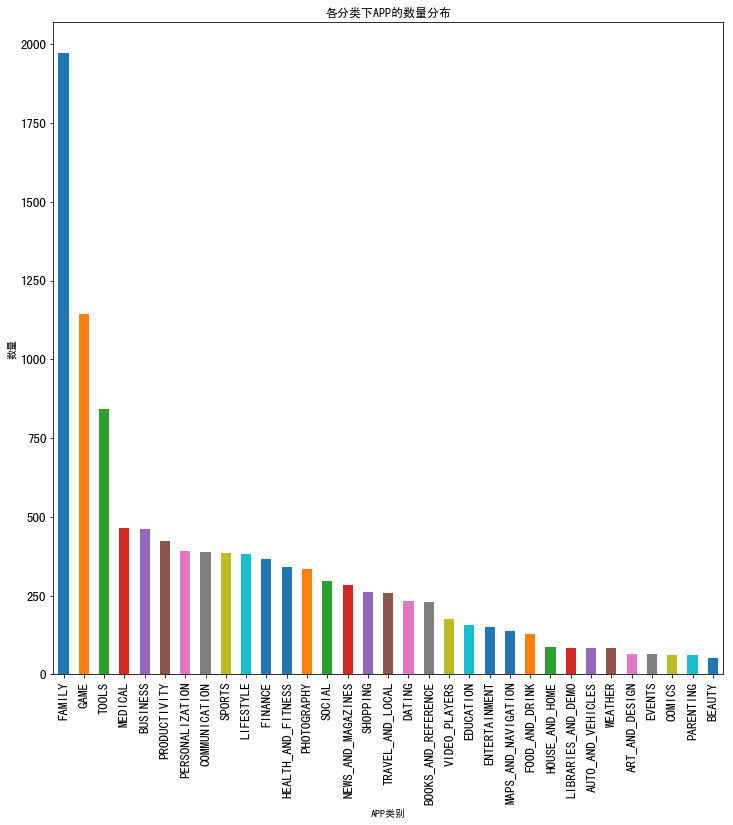

```python
df['Category'].value_counts().plot(kind='bar', figsize=(12, 12), fontsize=13)
plt.title('各分类下APP的数量分布')
plt.xlabel('APP类别')
plt.ylabel('数量')
plt.show()
```

家庭类、游戏类和工具类APP为类别的前三

**（2）Type数据**

```python
df['Type'].value_counts()
```

```
Free    10039
Paid      800
0           1
Name: Type, dtype: int64
```

免费类APP远多于付费类APP

**（3）内容分级**

```python
df['Content Rating'].value_counts()
```

```
Everyone           8714
Teen               1208
Mature 17+          499
Everyone 10+        414
Adults only 18+       3
Unrated               2
Name: Content Rating, dtype: int64
```

**（3）流派**

```python
df['Genres'].value_counts()
```

```
Tools                                  842
Entertainment                          623
Education                              549
Medical                                463
Business                               460
Productivity                           424
Sports                                 398
Personalization                        392
Communication                          387
Lifestyle                              381
Finance                                366
Action                                 365
Health & Fitness                       341
Photography                            335
Social                                 295
News & Magazines                       283
Shopping                               260
Travel & Local                         257
Dating                                 234
Books & Reference                      231
Arcade                                 220
Simulation                             200
Casual                                 193
Video Players & Editors                173
Puzzle                                 140
Maps & Navigation                      137
Food & Drink                           127
Role Playing                           109
Strategy                               107
Racing                                  98
                                      ...
Art & Design;Pretend Play                2
Entertainment;Pretend Play               2
Adventure;Education                      2
Strategy;Action & Adventure              2
Casual;Music & Video                     2
Card;Action & Adventure                  2
Lifestyle;Pretend Play                   1
Music & Audio;Music & Video              1
Entertainment;Education                  1
Tools;Education                          1
Health & Fitness;Action & Adventure      1
Comics;Creativity                        1
Role Playing;Brain Games                 1
Racing;Pretend Play                      1
Communication;Creativity                 1
Travel & Local;Action & Adventure        1
Trivia;Education                         1
Books & Reference;Creativity             1
Health & Fitness;Education               1
Adventure;Brain Games                    1
Strategy;Education                       1
Board;Pretend Play                       1
Arcade;Pretend Play                      1
Puzzle;Education                         1
Strategy;Creativity                      1
Card;Brain Games                         1
Role Playing;Education                   1
February 11, 2018                        1
Parenting;Brain Games                    1
Lifestyle;Education                      1
Name: Genres, Length: 120, dtype: int64
```

#### 2.2.3 查看缺失值

```python
# TO DO: clean the data (optional: only there are problems)
df.isnull().sum()
```

```
App                  0
Category             0
Rating            1474
Reviews              0
Size                 0
Installs             0
Type                 1
Price                0
Content Rating       1
Genres               0
Last Updated         0
Current Ver          8
Android Ver          3
reviews_num          0
installs_num         0
Price_num            0
dtype: int64
```

从以上的结果可以看出：

评分rating列有1474缺失值

类型Type和内容评级Content rating有1个缺失值

current version有8个缺失值

android version有3个缺失值

#### 2.2.4 查看重复数据

```python
df.duplicated().sum()
```

```
483
```

有483个重复数据

```python
# 按照App名称查看重复数据
df.duplicated(subset='App').sum()
```

```
698
```

部分App可能存在重复数据

### 2.3 初步清理数据

**删除异常数据**

通过以上对数据的初步解读，可以发现索引号10472这一行数据存在较多异常值、缺失值等，这里对该行数据做清除处理。

```python
df.drop(index=10472, inplace=True)
df[df['Rating']>5]
```

|  | App | Category | Rating | Reviews | Size | Installs | Type | Price | Content Rating | Genres | Last Updated | Current Ver | Android Ver | reviews_num | installs_num | Price_num |
| --- | --- | --- | --- | --- | --- | --- | --- | --- | --- | --- | --- | --- | --- | --- | --- | --- |

成功删除该行数据

**删除重复数据**

因为部分App存在重复数据，这里按照App这个subset删除重复数据

```python
df.drop_duplicates(subset='App', inplace=True)
df.shape
```

```
(9659, 16)
```

```python
df.duplicated(subset='App').sum()
```

```
0
```

成功删除重复数据

## 3 数据探索分析

### 3.1 分析Rating评分数据

```python
# 取出rating不缺失的数据
df_rating = df[df['Rating'].isnull()==False]
df_rating.head()
```

|  | App | Category | Rating | Reviews | Size | Installs | Type | Price | Content Rating | Genres | Last Updated | Current Ver | Android Ver | reviews_num | installs_num | Price_num |
| --- | --- | --- | --- | --- | --- | --- | --- | --- | --- | --- | --- | --- | --- | --- | --- | --- |
| 0 | Photo Editor & Candy Camera & Grid & ScrapBook | ART_AND_DESIGN | 4.1 | 159 | 19M | 10,000+ | Free | 0 | Everyone | Art & Design | January 7, 2018 | 1.0.0 | 4.0.3 and up | 159.0 | 10000.0 | 0.0 |
| 1 | Coloring book moana | ART_AND_DESIGN | 3.9 | 967 | 14M | 500,000+ | Free | 0 | Everyone | Art & Design;Pretend Play | January 15, 2018 | 2.0.0 | 4.0.3 and up | 967.0 | 500000.0 | 0.0 |
| 2 | U Launcher Lite – FREE Live Cool Themes, Hide ... | ART_AND_DESIGN | 4.7 | 87510 | 8.7M | 5,000,000+ | Free | 0 | Everyone | Art & Design | August 1, 2018 | 1.2.4 | 4.0.3 and up | 87510.0 | 5000000.0 | 0.0 |
| 3 | Sketch - Draw & Paint | ART_AND_DESIGN | 4.5 | 215644 | 25M | 50,000,000+ | Free | 0 | Teen | Art & Design | June 8, 2018 | Varies with device | 4.2 and up | 215644.0 | 50000000.0 | 0.0 |
| 4 | Pixel Draw - Number Art Coloring Book | ART_AND_DESIGN | 4.3 | 967 | 2.8M | 100,000+ | Free | 0 | Everyone | Art & Design;Creativity | June 20, 2018 | 1.1 | 4.4 and up | 967.0 | 100000.0 | 0.0 |

```python
# rating列数据进行排序
df_rating.sort_values(by='Rating', ascending=False, inplace=True)
df_rating.head(10)
```

|  | App | Category | Rating | Reviews | Size | Installs | Type | Price | Content Rating | Genres | Last Updated | Current Ver | Android Ver | reviews_num | installs_num | Price_num |
| --- | --- | --- | --- | --- | --- | --- | --- | --- | --- | --- | --- | --- | --- | --- | --- | --- |
| 9056 | Santa's Monster Shootout DX | GAME | 5.0 | 4 | 33M | 50+ | Paid | $1.99 | Teen | Action | August 15, 2013 | 1.05 | 2.2 and up | 4.0 | 50.0 | 1.99 |
| 8395 | DG TV | NEWS_AND_MAGAZINES | 5.0 | 3 | 5.7M | 100+ | Free | 0 | Everyone | News & Magazines | May 26, 2018 | 1.2 | 4.1 and up | 3.0 | 100.0 | 0.00 |
| 8493 | PK and DK Audio App | FAMILY | 5.0 | 2 | 3.9M | 100+ | Free | 0 | Everyone | Entertainment | October 25, 2017 | 5.1.4 | 4.1 and up | 2.0 | 100.0 | 0.00 |
| 6330 | HON. B.J. ACS COLLEGE ALE | FAMILY | 5.0 | 3 | 1.8M | 100+ | Free | 0 | Mature 17+ | Education | December 26, 2016 | 3.1 | 4.3 and up | 3.0 | 100.0 | 0.00 |
| 6342 | BJ Foods | BUSINESS | 5.0 | 3 | 1.5M | 10+ | Free | 0 | Everyone | Business | February 7, 2018 | 2.7 | 4.1 and up | 3.0 | 10.0 | 0.00 |
| 6363 | Read it easy for BK | LIFESTYLE | 5.0 | 1 | 3.2M | 50+ | Free | 0 | Everyone | Lifestyle | July 15, 2018 | 1.2 | 4.1 and up | 1.0 | 50.0 | 0.00 |
| 9766 | ER Assist | PRODUCTIVITY | 5.0 | 3 | 28M | 10+ | Free | 0 | Everyone | Productivity | December 6, 2016 | 0.1.7 | 4.1 and up | 3.0 | 10.0 | 0.00 |
| 6364 | BK Video Status | FAMILY | 5.0 | 13 | 2.1M | 100+ | Free | 0 | Everyone | Entertainment | July 7, 2018 | 2.3 | 4.4 and up | 13.0 | 100.0 | 0.00 |
| 6372 | BK Formula Calculator | TOOLS | 5.0 | 6 | 11M | 100+ | Free | 0 | Everyone | Tools | August 8, 2015 | 0.1.1 | 4.2 and up | 6.0 | 100.0 | 0.00 |
| 6375 | Dr Bk Sachin bhai | LIFESTYLE | 5.0 | 19 | 3.1M | 1,000+ | Free | 0 | Everyone | Lifestyle | December 7, 2017 | 2.2 | 4.1 and up | 19.0 | 1000.0 | 0.00 |

这里发现Rating评分前10的都是满分5分，考虑到评分数量reviews较少的APP的评分可能不够客观，接下来对评分Rating列和Reviews列共同排序。

```python
# 删除Rating缺失行后再排序
df_rating.sort_values(by=['Rating', 'reviews_num'], ascending=False, inplace=True)
df_rating.head(10)
```

|  | App | Category | Rating | Reviews | Size | Installs | Type | Price | Content Rating | Genres | Last Updated | Current Ver | Android Ver | reviews_num | installs_num | Price_num |
| --- | --- | --- | --- | --- | --- | --- | --- | --- | --- | --- | --- | --- | --- | --- | --- | --- |
| 10357 | Ríos de Fe | LIFESTYLE | 5.0 | 141 | 15M | 1,000+ | Free | 0 | Everyone | Lifestyle | March 24, 2018 | 1.8 | 4.1 and up | 141.0 | 1000.0 | 0.0 |
| 10301 | FD Calculator (EMI, SIP, RD & Loan Eligilibility) | FINANCE | 5.0 | 104 | 2.3M | 1,000+ | Free | 0 | Everyone | Finance | August 7, 2018 | 2.1.0 | 4.1 and up | 104.0 | 1000.0 | 0.0 |
| 8058 | Oración CX | LIFESTYLE | 5.0 | 103 | 3.8M | 5,000+ | Free | 0 | Everyone | Lifestyle | September 12, 2017 | 5.1.10 | 4.1 and up | 103.0 | 5000.0 | 0.0 |
| 6823 | Barisal University App-BU Face | FAMILY | 5.0 | 100 | 10M | 1,000+ | Free | 0 | Everyone | Education | May 6, 2018 | 3.1.1 | 4.0.3 and up | 100.0 | 1000.0 | 0.0 |
| 9496 | Master E.K | FAMILY | 5.0 | 90 | Varies with device | 1,000+ | Free | 0 | Everyone | Education | August 11, 2017 | 1.5.0 | 4.4 and up | 90.0 | 1000.0 | 0.0 |
| 7506 | CL REPL | TOOLS | 5.0 | 47 | 17M | 1,000+ | Free | 0 | Everyone | Tools | April 10, 2018 | 1.0.19 | 4.1 and up | 47.0 | 1000.0 | 0.0 |
| 5230 | AJ Cam | PHOTOGRAPHY | 5.0 | 44 | 2.8M | 100+ | Free | 0 | Everyone | Photography | January 23, 2018 | 1.0 | 4.1 and up | 44.0 | 100.0 | 0.0 |
| 9517 | Ek Vote | PRODUCTIVITY | 5.0 | 43 | 6.2M | 500+ | Free | 0 | Everyone | Productivity | November 7, 2017 | 1.1 | 4.0.3 and up | 43.0 | 500.0 | 0.0 |
| 5196 | AI Today : Artificial Intelligence News & AI 101 | NEWS_AND_MAGAZINES | 5.0 | 43 | 2.3M | 100+ | Free | 0 | Everyone | News & Magazines | June 22, 2018 | 1.0 | 4.4 and up | 43.0 | 100.0 | 0.0 |
| 7842 | CS & IT Interview Questions | FAMILY | 5.0 | 43 | 3.3M | 1,000+ | Free | 0 | Everyone | Education | March 27, 2018 | 1.1 | 4.2 and up | 43.0 | 1000.0 | 0.0 |

```python
# 将df_rating分为付费类df_rpaid和免费类df_rfree
df_rpaid = df_rating[df['Type']=='Paid']
df_rfree = df_rating[df['Type']=='Free']
print('付费类APP评分从高到低排序TOP10:')
print(df_rpaid['App'][0:10])
print('免费类APP评分从高到低排序TOP10:')
print(df_rfree['App'][0:10])
```

```
付费类APP评分从高到低排序TOP10:
9010           RETRO Shocked DW-6000
5237          Hey AJ! It's Saturday!
7100                     CA Speakers
8014                    Morse Player
7466                          211:CK
9039                   Chronolink DX
5966                    BC MVA Fines
10690                       FO Bixby
9056     Santa's Monster Shootout DX
4452                 P-Home for KLWP
Name: App, dtype: object
免费类APP评分从高到低排序TOP10:
10357                                           Ríos de Fe
10301    FD Calculator (EMI, SIP, RD & Loan Eligilibility)
8058                                            Oración CX
6823                        Barisal University App-BU Face
9496                                            Master E.K
7506                                               CL REPL
5230                                                AJ Cam
9517                                               Ek Vote
5196      AI Today : Artificial Intelligence News & AI 101
7842                           CS & IT Interview Questions
Name: App, dtype: object
```

最高评分的付费类APP：RETRO Shocked DW-6000

最高付费的免费类APP：Ríos de Fe

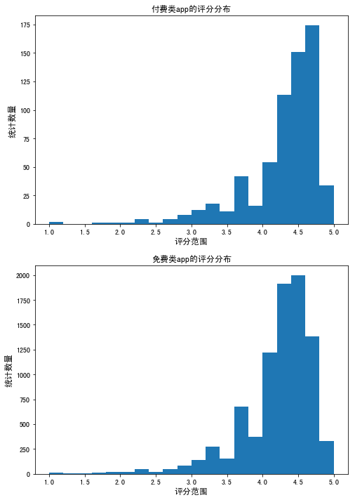

```python
# 绘制付费类和免费类app的Rating评分的分布情况
fig = plt.figure(figsize=(8,12))

# 付费类app评分分布
ax1 = fig.add_subplot(2,1,1)
ax1.hist(df_rpaid['Rating'], bins=20)
ax1.set_title('付费类app的评分分布', fontsize=12)
ax1.set_xlabel('评分范围', fontsize=12)
ax1.set_ylabel('统计数量', fontsize=12)
# 免费类app评分分布
#ax2 = ax1.twinx()
ax2 = fig.add_subplot(2,1,2)
ax2.hist(df_rfree['Rating'], bins=20)
ax2.set_title('免费类app的评分分布', fontsize=12)
ax2.set_xlabel('评分范围', fontsize=12)
ax2.set_ylabel('统计数量', fontsize=12)

# plt.tight_layout()
plt.show()
```

仅从上述图形来看，付费类app分布在4.5分以上的比例比免费类app高，一定程度上可以认为付费类app的评分更高，或者说付费类app的体验会更好。

**分别查看付费类和免费类app的评分统计特性**

```python
df_rpaid['Rating'].describe()
```

```
count    647.000000
mean       4.266615
std        0.547523
min        1.000000
25%        4.100000
50%        4.400000
75%        4.600000
max        5.000000
Name: Rating, dtype: float64
```

```python
df_rfree['Rating'].describe()
```

```
count    8719.000000
mean        4.186203
std         0.512338
min         1.000000
25%         4.000000
50%         4.300000
75%         4.500000
max         5.000000
Name: Rating, dtype: float64
```

评分的均值和中位数均是付费类app更高，综合分布图分析结果，可以认为付费类app更容易获得高分，或者说付费类app的体验会更好。

**付费类app的评分和价格的关系**

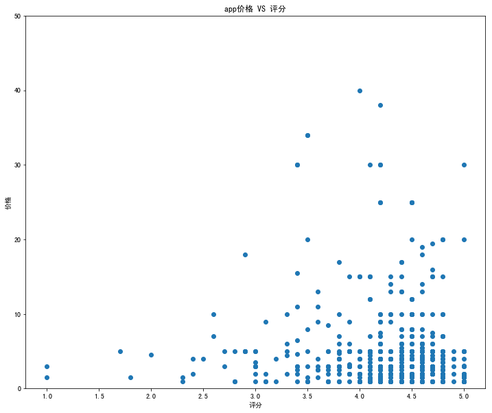

```python
# 画出评分和价格的散点图
plt.subplots(figsize=(12, 10))
price_arr = np.array(df_rpaid['Price_num'])
rating_arr = np.array(df_rpaid['Rating'])
# 画出散点图
plt.scatter(rating_arr, price_arr)
# plt.scatter(price_arr, rating_arr)
# 部分app价格很高，不便于观察，限制
plt.ylim(0, 50)
plt.title('app价格 VS 评分')
plt.xlabel('评分')
plt.ylabel('价格')
plt.show()
```

### 3.2 分析Installs下载量数据

**下载量排序**

```python
# 将数据按照下载量从高到低排序，并打印前10的结果
df.sort_values(by='installs_num', ascending=False, inplace=True)
df.head(10)
```

|  | App | Category | Rating | Reviews | Size | Installs | Type | Price | Content Rating | Genres | Last Updated | Current Ver | Android Ver | reviews_num | installs_num | Price_num |
| --- | --- | --- | --- | --- | --- | --- | --- | --- | --- | --- | --- | --- | --- | --- | --- | --- |
| 2544 | Facebook | SOCIAL | 4.1 | 78158306 | Varies with device | 1,000,000,000+ | Free | 0 | Teen | Social | August 3, 2018 | Varies with device | Varies with device | 78158306.0 | 1.000000e+09 | 0.0 |
| 386 | Hangouts | COMMUNICATION | 4.0 | 3419433 | Varies with device | 1,000,000,000+ | Free | 0 | Everyone | Communication | July 21, 2018 | Varies with device | Varies with device | 3419433.0 | 1.000000e+09 | 0.0 |
| 3234 | Google | TOOLS | 4.4 | 8033493 | Varies with device | 1,000,000,000+ | Free | 0 | Everyone | Tools | August 3, 2018 | Varies with device | Varies with device | 8033493.0 | 1.000000e+09 | 0.0 |
| 4150 | Google | TOOLS | 4.4 | 8021623 | Varies with device | 1,000,000,000+ | Free | 0 | Everyone | Tools | August 3, 2018 | Varies with device | Varies with device | 8021623.0 | 1.000000e+09 | 0.0 |
| 5856 | Google Play Games | FAMILY | 4.3 | 7168735 | Varies with device | 1,000,000,000+ | Free | 0 | Teen | Entertainment | July 16, 2018 | Varies with device | Varies with device | 7168735.0 | 1.000000e+09 | 0.0 |
| 865 | Google Play Games | ENTERTAINMENT | 4.3 | 7165362 | Varies with device | 1,000,000,000+ | Free | 0 | Teen | Entertainment | July 16, 2018 | Varies with device | Varies with device | 7165362.0 | 1.000000e+09 | 0.0 |
| 2554 | Google+ | SOCIAL | 4.2 | 4831125 | Varies with device | 1,000,000,000+ | Free | 0 | Teen | Social | July 26, 2018 | Varies with device | Varies with device | 4831125.0 | 1.000000e+09 | 0.0 |
| 4144 | Google+ | SOCIAL | 4.2 | 4828372 | Varies with device | 1,000,000,000+ | Free | 0 | Teen | Social | July 26, 2018 | Varies with device | Varies with device | 4828372.0 | 1.000000e+09 | 0.0 |
| 451 | Gmail | COMMUNICATION | 4.3 | 4604483 | Varies with device | 1,000,000,000+ | Free | 0 | Everyone | Communication | August 2, 2018 | Varies with device | Varies with device | 4604483.0 | 1.000000e+09 | 0.0 |
| 4096 | Gmail | COMMUNICATION | 4.3 | 4604324 | Varies with device | 1,000,000,000+ | Free | 0 | Everyone | Communication | August 2, 2018 | Varies with device | Varies with device | 4604324.0 | 1.000000e+09 | 0.0 |

```python
# 将数据按照下载量和评论数量从高到低排序，并打印前10的结果
df.sort_values(by=['installs_num', 'reviews_num'], ascending=False, inplace=True)
df.head(10)
```

|  | App | Category | Rating | Reviews | Size | Installs | Type | Price | Content Rating | Genres | Last Updated | Current Ver | Android Ver | reviews_num | installs_num | Price_num |
| --- | --- | --- | --- | --- | --- | --- | --- | --- | --- | --- | --- | --- | --- | --- | --- | --- |
| 2544 | Facebook | SOCIAL | 4.1 | 78158306 | Varies with device | 1,000,000,000+ | Free | 0 | Teen | Social | August 3, 2018 | Varies with device | Varies with device | 78158306.0 | 1.000000e+09 | 0.0 |
| 336 | WhatsApp Messenger | COMMUNICATION | 4.4 | 69119316 | Varies with device | 1,000,000,000+ | Free | 0 | Everyone | Communication | August 3, 2018 | Varies with device | Varies with device | 69119316.0 | 1.000000e+09 | 0.0 |
| 2604 | Instagram | SOCIAL | 4.5 | 66577446 | Varies with device | 1,000,000,000+ | Free | 0 | Teen | Social | July 31, 2018 | Varies with device | Varies with device | 66577446.0 | 1.000000e+09 | 0.0 |
| 382 | Messenger – Text and Video Chat for Free | COMMUNICATION | 4.0 | 56646578 | Varies with device | 1,000,000,000+ | Free | 0 | Everyone | Communication | August 1, 2018 | Varies with device | Varies with device | 56646578.0 | 1.000000e+09 | 0.0 |
| 1872 | Subway Surfers | GAME | 4.5 | 27725352 | 76M | 1,000,000,000+ | Free | 0 | Everyone 10+ | Arcade | July 12, 2018 | 1.90.0 | 4.1 and up | 27725352.0 | 1.000000e+09 | 0.0 |
| 3665 | YouTube | VIDEO_PLAYERS | 4.3 | 25655305 | Varies with device | 1,000,000,000+ | Free | 0 | Teen | Video Players & Editors | August 2, 2018 | Varies with device | Varies with device | 25655305.0 | 1.000000e+09 | 0.0 |
| 2884 | Google Photos | PHOTOGRAPHY | 4.5 | 10859051 | Varies with device | 1,000,000,000+ | Free | 0 | Everyone | Photography | August 6, 2018 | Varies with device | Varies with device | 10859051.0 | 1.000000e+09 | 0.0 |
| 4234 | Skype - free IM & video calls | COMMUNICATION | 4.1 | 10484169 | Varies with device | 1,000,000,000+ | Free | 0 | Everyone | Communication | August 3, 2018 | Varies with device | Varies with device | 10484169.0 | 1.000000e+09 | 0.0 |
| 411 | Google Chrome: Fast & Secure | COMMUNICATION | 4.3 | 9643041 | Varies with device | 1,000,000,000+ | Free | 0 | Everyone | Communication | August 1, 2018 | Varies with device | Varies with device | 9643041.0 | 1.000000e+09 | 0.0 |
| 3223 | Maps - Navigate & Explore | TRAVEL_AND_LOCAL | 4.3 | 9235373 | Varies with device | 1,000,000,000+ | Free | 0 | Everyone | Travel & Local | July 31, 2018 | Varies with device | Varies with device | 9235373.0 | 1.000000e+09 | 0.0 |

可以看出，下载量和评论量的TOP10的APP主要社交和通信相关的APP，其中下载量和评论量最大的APP是Facebook

Facebook妥妥的全球最大的社交App公司

**下载量和评论量关系**

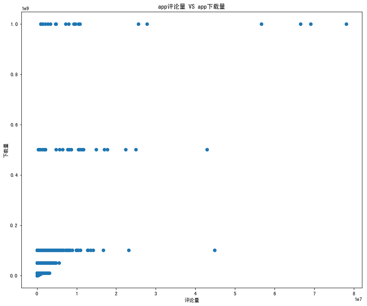

```python
# 画出评分和价格的散点图
plt.subplots(figsize=(12, 10))
reviews_arr = np.array(df['reviews_num'])
installs_arr = np.array(df['installs_num'])
# 画出散点图
plt.scatter(reviews_arr, installs_arr)

plt.title('app评论量 VS app下载量')
plt.xlabel('评论量')
plt.ylabel('下载量')
plt.show()
```

大体上，下载量更大的app有更大的评论量，但是也存在下载量更大但评论量更小的情况。

**下载量和价格关系**

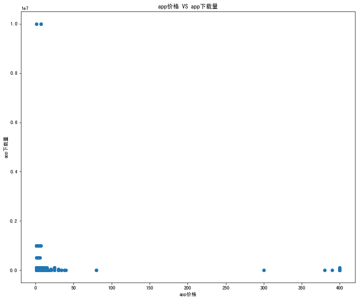

```python
# 画出评分和价格的散点图
plt.subplots(figsize=(12, 10))
price_arr = np.array(df_rpaid['Price_num'])
installs_arr = np.array(df_rpaid['installs_num'])
# 画出散点图
plt.scatter(price_arr, installs_arr)

plt.title('app价格 VS app下载量')
plt.xlabel('app价格')
plt.ylabel('app下载量')
plt.show()
```

从上图可以看出，价格更低的app确实可以获得更高的下载量，但是也出现了400刀的app下载量相对中间价位app更高下载量的情况，说明即使app的价格再高，只要大家有使用的需求或该app有很好的口碑，价格高昂的app的下载量应该也不会小。

## 得出结论

**问题**：上面的分析能够回答你提出的问题？通过这些分析你能够得出哪些结论？

## 反思

**问题**：在你的分析和总结过程中是否存在逻辑严谨。是否有改进的空间? 你可以从下面的一些角度进行思考：

1. 数据集是否完整，包含所有想要分析的数据？
2. 在对数据进行处理的时候，你的操作（例如删除/填充缺失值）是否可能影响结论？
3. 是否还有其他变量（本数据中没有）能够对你的分析有帮助？
4. 在得出结论时，你是否混淆了相关性和因果性？

**答案**：

1. 数据集不完整，但包含了提出问题需要的数据。
2. 处理数据时，尽量避免了影响结论，但删除重复值的时候，直接删除了APP名称重复的数据，但是它们的其他列的数据并不相同，可能会影响分析的结论。
3. 暂时没有想到还需要什么变量，毕竟Project提供的变量都没有完全使用，其实还可以更深入的对分析中没有涉及的变量进行分析，比如分析下载量、评分是否与APP的类型相关。
4. 感觉没有吧。还请老师指点，谢谢。

恭喜你完成了此项目！这只是数据分析过程的一个样本：从生成问题、整理数据、探索数据到得出结论。在数据分析(进阶)纳米学位中，你将会学到更多高级的数据分析方法和技术，如果你感兴趣的话，我们鼓励你继续学习后续的课程，掌握更多的数据分析的高级技能！

> 若想与他人分享我们的分析结果，除了向他们提供 jupyter Notebook (.ipynb) 文件的副本外，我们还可以将 Notebook 输出导出为一种甚至那些未安装 Python 的人都能打开的形式。从左上方的“文件”菜单，前往“下载为”子菜单。然后你可以选择一个可以更普遍查看的格式，例如 HTML (.html) 。你可能需要额外软件包或软件来执行这些导出。